# Chapter 07: Analysis of Function: Sentence Modes

7.5.2 Register-tier analysis of intonational phonology

## Raw Data

### Contour by sentence mode

```r
m_corpus %>%
  group_by(mode, nuc_contour) %>%
  summarise(acc_count = n(), .groups = "keep") %>%
  pivot_wider(
    names_from = nuc_contour,
    values_from = acc_count,
    values_fill = 0
  ) %>%
  adorn_totals(where = "row") %>%
  select(
    c(
      "mode",
      "H* L%",
      ">H* L%",
      "^[L*]H L%",
      "L*H %",
      "L*H L%",
      "L*^[H] %",
      "L*^[H L%]",
      "L*^[H] L%",
      "^[L*H] %",
      "^[L*H L%]",
      "^[L*H] L%"
    )
  ) %>%
  rename_all(list(~ str_replace_all(., "([\\*\\[\\^\\>])", "\\\\\\1"))) %>%
  formattable(
    align = c("l", rep("r", ncol(.) - 1)),
    caption = "Nuclear contours by mode in M-corpus (raw)"
  )
```

Nuclear contours by mode in M-corpus (raw)

| mode | H* L% | >H* L% | ^[L*]H L% | L*H % | L*H L% | L*^[H] % | L*^[H L%] | L*^[H] L% | ^[L*H] % | ^[L*H L%] | ^[L*H] L% |
| --- | --- | --- | --- | --- | --- | --- | --- | --- | --- | --- | --- |
| MDC | 2 | 2 | 0 | 141 | 18 | 0 | 0 | 0 | 0 | 0 | 0 |
| MWH | 0 | 0 | 0 | 144 | 17 | 0 | 0 | 0 | 0 | 0 | 0 |
| MYN | 0 | 2 | 3 | 97 | 18 | 5 | 0 | 0 | 30 | 6 | 1 |
| MDQ | 0 | 1 | 3 | 37 | 6 | 17 | 6 | 2 | 51 | 12 | 18 |
| Total | 2 | 5 | 6 | 419 | 59 | 22 | 6 | 2 | 81 | 18 | 19 |

### Pitch accents by speaker

```r
# Create summary table of Pitch Accent by Speaker.


m_corpus %>%
  group_by(speaker, acc_phon) %>%
  summarise(acc_count = n(), .groups = "keep") %>%
  pivot_wider(
    names_from = acc_phon,
    values_from = acc_count,
    values_fill = 0
  ) %>%
  select("speaker", "H*", "^[L*]H", ">H*", "L*H", "L*^[H]", "^[L*H]") %>%
  rename_all(list(~ str_replace_all(., "([\\*\\[\\^\\>])", "\\\\\\1"))) %>%
  adorn_totals(where = "row") %>%
  formattable(
    align = c("l", rep("r", ncol(.) - 1)),
    caption =
      "Distibution by speaker of nuclear pitch accents in M-corpus (raw)",
    list(area(col = 2:7, row = 1:nrow(.) - 1) ~ proportion_bar(color = c(
      rep(brewer.pal(6, "Pastel2")[1], nrow(.) - 1),
      rep(brewer.pal(6, "Pastel2")[5], nrow(.) - 1),
      rep(brewer.pal(6, "Pastel2")[4], nrow(.) - 1),
      rep(brewer.pal(6, "Pastel2")[3], nrow(.) - 1),
      rep(brewer.pal(6, "Pastel2")[2], nrow(.) - 1),
      rep(brewer.pal(6, "Pastel2")[6], nrow(.) - 1)
    )))
  )
```

Distibution by speaker of nuclear pitch accents in M-corpus (raw)

| speaker | H* | ^[L*]H | >H* | L*H | L*^[H] | ^[L*H] |
| --- | --- | --- | --- | --- | --- | --- |
| F5 | 0 | 0 | 0 | 45 | 13 | 1 |
| F6 | 0 | 0 | 0 | 51 | 5 | 4 |
| F12 | 0 | 0 | 0 | 45 | 1 | 14 |
| F15 | 0 | 0 | 0 | 51 | 4 | 5 |
| F16 | 0 | 0 | 0 | 59 | 1 | 0 |
| F17 | 0 | 0 | 0 | 47 | 1 | 7 |
| M4 | 0 | 0 | 0 | 36 | 5 | 16 |
| M5 | 0 | 0 | 0 | 36 | 0 | 24 |
| M8 | 2 | 6 | 5 | 29 | 0 | 19 |
| M9 | 0 | 0 | 0 | 40 | 0 | 7 |
| M10 | 0 | 0 | 0 | 52 | 0 | 8 |
| Total | 2 | 6 | 5 | 491 | 30 | 105 |

### All pitch contours

```r
# Create summary table of Pitch Accent by Speaker.
m_corpus %>%
  group_by(nuc_contour) %>%
  summarise(nuc_count = n(), .groups = "keep") %>%
  mutate(nuc_contour = str_replace_all(
    nuc_contour, "([\\*\\[\\^\\>])", "\\\\\\1"
  )) %>%
  rename(
    `nuclear contour` = nuc_contour,
    `count` = nuc_count
  ) %>%
  arrange(desc(`count`)) %>%
  kable(caption = "Nuclear pitch contours (raw data)")
```

Nuclear pitch contours (raw data)

| nuclear contour | count |
| --- | --- |
| L*H % | 419 |
| ^[L*H] % | 81 |
| L*H L% | 59 |
| L*^[H] % | 22 |
| ^[L*H] L% | 19 |
| ^[L*H L%] | 18 |
| ^[L*]H L% | 6 |
| L*^[H L%] | 6 |
| >H* L% | 5 |
| H* L% | 2 |
| L*^[H] L% | 2 |

## Adjusted Data

The raw data is unbalanced since the number of utterances per target speaker varies slightly. For some speakers, there are no repetitions of some target utterances. Therefore, the data has been adjusted to project an estimated balanced number of tokens per speaker per target utterance.

Firstly a tibble is created summarising the proportion of pitch accents per mode per speaker. This is done in three initial stages:

1. Count the number of phonological tokens per stimulus per speaker.
2. Convert the counts to proportion per stimulus per speaker.
3. Convert the proportion per stimulus per speaker to a proportion per stimulus per mode.

From this table summary tables are created:

1. pitch accents per speaker (adjusted)
   1. Calculate the sum all proportions per token per speaker.
   2. Convert proportions to an integer based on an ideal total number of tokens per speaker.
2. pitch accents per mode (adjusted):
   1. Calculate the sum all proportions per token per mode.
   2. Convert proportions to an integer based on an ideal total number of tokens per mode
3. pitch accents by gender and mode (adjusted):
   1. Calculate the sum all proportions per token by mode and gender.
2. Convert proportions to an integer based on an ideal total number of tokens per mode as if there were an equal numnber of male and female participants.

```r
# Create tibble summarising  proportion of pitch accents per mode per speaker
#
pa_adj <- m_corpus %>%
  # Count the number of acc_phon by speaker and mode
  group_by(speaker, stim, acc_phon) %>%
  summarise(nuc_count = n(), .groups = "keep") %>%
  pivot_wider(names_from = acc_phon, values_from = nuc_count, values_fill = 0) %>%
  # convert the totals to proportion per stim.
  adorn_totals("col") %>%
  mutate(across(3:8, ~ (. / Total))) %>%
  select(-Total) %>%
  # Convert stim column to mode.
  rename(mode = stim) %>%
  mutate(mode = substr(mode, 1, 3)) %>%
  # Convert the values to proportion per mode
  pivot_longer(3:last_col(), "acc_phon") %>%
  group_by(speaker, mode, acc_phon) %>%
  pivot_wider(
    names_from = acc_phon,
    values_from = value,
    values_fill = 0,
    values_fn = ~ sum(.)
  ) %>%
  adorn_totals("col") %>%
  mutate(across(3:8, ~ (. / Total)),
    mode = factor(mode, levels = c("MDC", "MWH", "MYN", "MDQ"))
  ) %>%
  select(-Total) %>%
  as_tibble()


# Create tibble of pitch accents per speaker (adjusted).
#
pa_by_speaker_adj <- pa_adj %>%
  # Get the sum of all token proportions per speaker.
  pivot_longer(3:last_col(), "acc_phon") %>%
  select(-mode) %>%
  pivot_wider(
    names_from = acc_phon,
    values_from = value,
    values_fill = 0,
    values_fn = ~ sum(.)
  ) %>%
  # Convert proportions to an integer based on an ideal total number of tokens
  # per speaker.
  mutate(across(2:7, ~ round(. * 15, 0))) %>%
  select("speaker", "H*", ">H*", "^[L*]H", "L*H", "L*^[H]", "^[L*H]")


# Create tibble of pitch accents per mode (adjusted).
#
pa_by_mode_adj <- pa_adj %>%
  # Get the sum of all token proportions per speaker.
  pivot_longer(3:last_col(), "acc_phon") %>%
  select(-speaker) %>%
  pivot_wider(
    names_from = acc_phon,
    values_from = value,
    values_fill = 0,
    values_fn = ~ sum(.)
  ) %>%
  # Convert proportions to an integer based on an ideal total number of tokens.
  mutate(across(2:7, ~ round(. * 15, 0))) %>%
  select("mode", "H*", ">H*", "^[L*]H", "L*H", "L*^[H]", "^[L*H]") %>%
  arrange(mode)


# Create tibble of pitch accents by gender and mode (adjusted).
#
pa_by_gender_adj <- pa_adj %>%
  # Convert gender to speaker
  mutate(
    speaker = substr(speaker, 1, 1),
    speaker = factor(speaker, levels = unique(speaker))
  ) %>%
  rename(gender = speaker) %>%
  # Get the sum of all token proportions per speaker.
  pivot_longer(3:last_col(), "acc_phon") %>%
  pivot_wider(
    names_from = acc_phon,
    values_from = value,
    values_fill = 0,
    values_fn = ~ sum(.)
  ) %>%
  # Convert proportions to an integer based on an ideal total number of tokens
  # per speaker.
  mutate(across(3:8, ~ if_else(gender == "F",
    round(. * 15, 0),
    # project equal number of Male & Female speakers.
    round(. * 18, 0)
  ))) %>%
  select("mode", "gender", "H*", ">H*", "^[L*]H", "L*H", "L*^[H]", "^[L*H]") %>%
  arrange(mode)


# Create tibble of pitch accents by gender and mode (adjusted).
#
pa_by_mode_speaker_adj <- pa_adj %>%
  # Get the sum of all token proportions per speaker.
  pivot_longer(3:last_col(), "acc_phon") %>%
  pivot_wider(
    names_from = acc_phon,
    values_from = value,
    values_fill = 0,
    values_fn = ~ sum(.)
  ) %>%
  # Convert proportions to integer based on ideal number of by-speaker tokens.
  mutate(across(3:last_col(), ~ round(. * 16))) %>%
  # re-order the columns
  select("mode", "speaker", "H*", ">H*", "^[L*]H", "L*H", "L*^[H]", "^[L*H]") %>%
  arrange(speaker)
```

### Nuclear PA Tables

#### by mode (common)

```r
pa_by_mode_adj %>%
  select("mode", "L*H", "L*^[H]", "^[L*H]") %>%
  rename_all(list(~ str_replace_all(., "([\\*\\[\\^\\>])", "\\\\\\1"))) %>%
  adorn_totals("row") %>%
  formattable(
    align = c("l", rep("r", ncol(.) - 1)),
    caption = paste(
      "Distibution by of pitch accents by mode in M-corpus",
      "(adjusted, outliers excluded)"
    ),
    list(area(col = 2:4, row = 1:nrow(.) - 1) ~ proportion_bar(color = c(
      rep(brewer.pal(6, "Pastel2")[3], 4),
      rep(brewer.pal(6, "Pastel2")[2], 4),
      rep(brewer.pal(6, "Pastel2")[6], 4)
    )))
  )
```

Distibution by of pitch accents by mode in M-corpus (adjusted, outliers excluded)

| mode | L*H | L*^[H] | ^[L*H] |
| --- | --- | --- | --- |
| MDC | 162 | 0 | 0 |
| MWH | 165 | 0 | 0 |
| MYN | 117 | 5 | 38 |
| MDQ | 62 | 25 | 74 |
| Total | 506 | 30 | 112 |

#### by mode (all)

```r
# Calculate a projected balanced number of tokens for each PA as a function of # sentence mode.
#
# This takes into consideration the number of utterances per speaker per stimulus and the number of speakers per stimulus.

pa_by_mode_adj %>%
  rename_all(list(~ str_replace_all(., "([\\*\\[\\^\\>])", "\\\\\\1"))) %>%
  adorn_totals("row") %>%
  formattable(
    align = c("l", rep("r", ncol(.) - 1)),
    caption =
      "Distibution by mode of nuclear pitch accents in M-corpus (adjusted)",
    list(area(col = 2:7, row = 1:4) ~ proportion_bar(color = c(
      rep(brewer.pal(6, "Pastel2")[1], nrow(.) - 1),
      rep(brewer.pal(6, "Pastel2")[4], nrow(.) - 1),
      rep(brewer.pal(6, "Pastel2")[5], nrow(.) - 1),
      rep(brewer.pal(6, "Pastel2")[3], nrow(.) - 1),
      rep(brewer.pal(6, "Pastel2")[2], nrow(.) - 1),
      rep(brewer.pal(6, "Pastel2")[6], nrow(.) - 1)
    )))
  )
```

Distibution by mode of nuclear pitch accents in M-corpus (adjusted)

| mode | H* | >H* | ^[L*]H | L*H | L*^[H] | ^[L*H] |
| --- | --- | --- | --- | --- | --- | --- |
| MDC | 2 | 2 | 0 | 162 | 0 | 0 |
| MWH | 0 | 0 | 0 | 165 | 0 | 0 |
| MYN | 0 | 2 | 3 | 117 | 5 | 38 |
| MDQ | 0 | 1 | 3 | 62 | 25 | 74 |
| Total | 2 | 5 | 6 | 506 | 30 | 112 |

#### by speaker

```r
pa_by_speaker_adj %>%
  rename_all(list(~ str_replace_all(., "([\\*\\[\\^\\>])", "\\\\\\1"))) %>%
  adorn_totals(where = "row") %>%
  formattable(
    align = c("l", rep("r", ncol(.) - 1)),
    caption = "Distibution by speaker of nuclear pitch accents in M-corpus (adjusted)",
    list(area(col = 2:7, row = 1:nrow(.) - 1) ~ proportion_bar(color = c(
      rep(brewer.pal(6, "Pastel2")[1], nrow(.) - 1),
      rep(brewer.pal(6, "Pastel2")[4], nrow(.) - 1),
      rep(brewer.pal(6, "Pastel2")[5], nrow(.) - 1),
      rep(brewer.pal(6, "Pastel2")[3], nrow(.) - 1),
      rep(brewer.pal(6, "Pastel2")[2], nrow(.) - 1),
      rep(brewer.pal(6, "Pastel2")[6], nrow(.) - 1)
    )))
  )
```

Distibution by speaker of nuclear pitch accents in M-corpus (adjusted)

| speaker | H* | >H* | ^[L*]H | L*H | L*^[H] | ^[L*H] |
| --- | --- | --- | --- | --- | --- | --- |
| F5 | 0 | 0 | 0 | 46 | 13 | 1 |
| F6 | 0 | 0 | 0 | 51 | 5 | 4 |
| F12 | 0 | 0 | 0 | 45 | 1 | 14 |
| F15 | 0 | 0 | 0 | 51 | 4 | 5 |
| F16 | 0 | 0 | 0 | 59 | 1 | 0 |
| F17 | 0 | 0 | 0 | 52 | 1 | 7 |
| M4 | 0 | 0 | 0 | 36 | 5 | 19 |
| M5 | 0 | 0 | 0 | 36 | 0 | 24 |
| M8 | 2 | 5 | 6 | 29 | 0 | 19 |
| M9 | 0 | 0 | 0 | 49 | 0 | 11 |
| M10 | 0 | 0 | 0 | 52 | 0 | 8 |
| Total | 2 | 5 | 6 | 506 | 30 | 112 |

### Nuclear PA Figures

#### by speaker (chart)

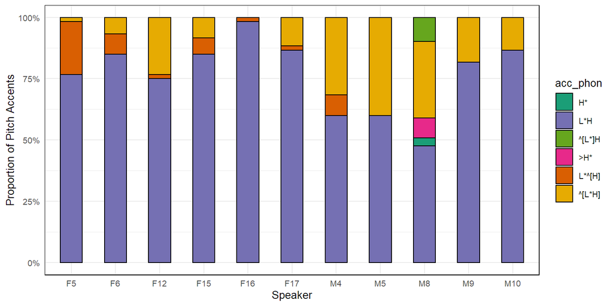

```r
# Percentage Stacked bar
ggplot(
  data = pa_by_speaker_adj %>%
    # uncount data for plotting
    gather("acc_phon", "count", -c(speaker)) %>%
    uncount(count),
  aes(fill = acc_phon, x = speaker)
) +
  geom_bar(
    stat = "count",
    position = "fill",
    width = 0.50,
    colour = "black"
  ) +
  scale_y_continuous(labels = scales::label_percent(scale = 100)) +
  scale_fill_manual(values = pitch_accent_colours[1:6]) +
  labs(
    y = "Proportion of Pitch Accents",
    x = "Speaker"
  ) +
  theme(panel.border = element_rect(fill = NA))
```

#### by mode (common)

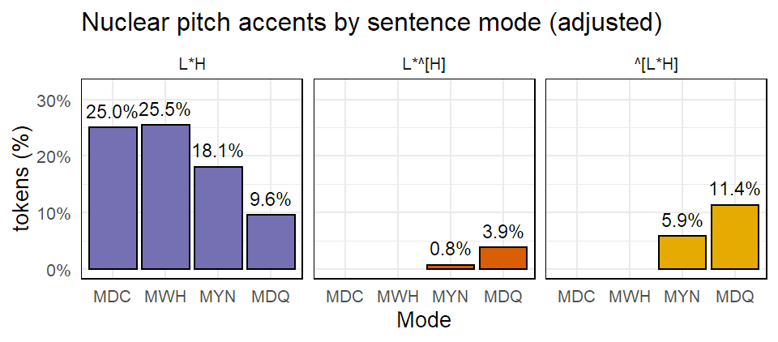

```r
ggplot(pa_by_mode_adj %>%
  # uncount table for bar chart
  pivot_longer(2:last_col(), "acc_phon") %>%
  uncount(value) %>%
  # exclude outliers.
  filter(acc_phon %in% c("L*H", "L*^[H]", "^[L*H]")) %>%
  mutate(acc_phon = factor(acc_phon,
    levels = c("L*H", "L*^[H]", "^[L*H]")
  ))) +
  geom_bar(
    mapping = aes(
      x = mode,
      y = (..count..) / sum(..count..),
      fill = acc_phon
    ),
    show.legend = F,
    colour = "black",
    position = position_dodge2(preserve = "single")
  ) +
  scale_y_continuous(labels = scales::percent, limits = c(0, 0.32)) +
  facet_grid(cols = vars(acc_phon)) +
  theme(panel.border = element_rect(fill = NA)) +
  ggtitle("Nuclear pitch accents by sentence mode (adjusted)") +
  scale_fill_manual(values = pitch_accent_colours, name = "Pitch Accent") +
  labs(x = "Mode", y = "tokens (%)") +
  theme(panel.border = element_rect(fill = NA)) +
  geom_text(aes(
    x = mode,
    y = (..count..) / sum(..count..),
    label = percent((..count..) / sum(..count..), 1)
  ),
  stat = "count",
  vjust = -0.7,
  size = 3
  )
```

#### by mode (all)

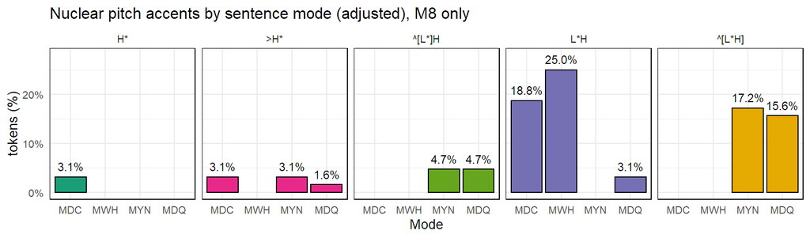

```r
ggplot(
  pa_by_mode_speaker_adj %>%
    filter(speaker == "M8") %>%
    # Uncount tables bar chart.
    pivot_longer(3:last_col(), "acc_phon") %>%
    uncount(value) %>%
    mutate(acc_phon = factor(
      acc_phon,
      levels = c("H*", ">H*", "^[L*]H", "L*H", "L*^[H]", "^[L*H]")
    ))
) +
  geom_bar(
    mapping = aes(
      x = mode,
      y = (..count..) / sum(..count..),
      fill = acc_phon
    ),
    show.legend = F,
    colour = "black",
    position = position_dodge2(preserve = "single")
  ) +
  scale_y_continuous(labels = scales::percent, limits = c(0, 0.28)) +
  facet_grid(cols = vars(acc_phon)) +
  ggtitle("Nuclear pitch accents by sentence mode (adjusted), M8 only") +
  theme(
    panel.border = element_rect(fill = NA)
  ) +
  scale_fill_manual(values = pitch_accent_colours, name = "Pitch Accent") +
  labs(x = "Mode", y = "tokens (%)") +
  theme(panel.border = element_rect(fill = NA)) +
  geom_text(aes(
    x = mode,
    y = (..count..) / sum(..count..),
    label = percent((..count..) / sum(..count..), 1)
  ),
  stat = "count",
  vjust = -0.7,
  size = 3
  )
```

#### by mode and gender (common)

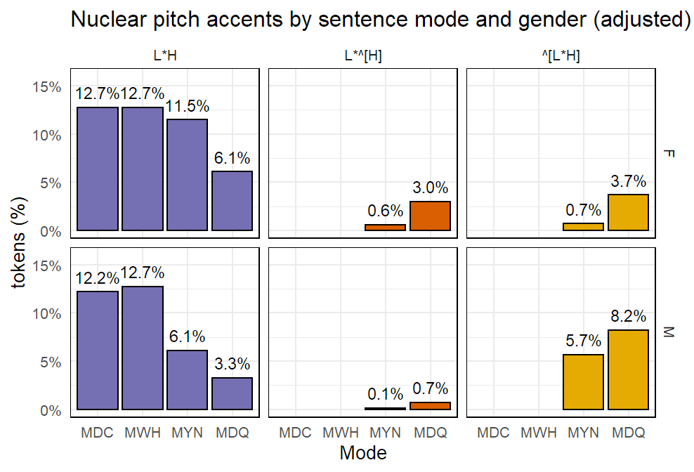

```r
ggplot(pa_by_gender_adj %>%
  # Uncount tables bar chart.
  pivot_longer(3:last_col(), "acc_phon") %>%
  uncount(value) %>%
  # Exclude outliers.
  filter(acc_phon %in% c("L*H", "L*^[H]", "^[L*H]")) %>%
  mutate(acc_phon = factor(acc_phon, levels = c("L*H", "L*^[H]", "^[L*H]")))) +
  geom_bar(
    mapping = aes(
      x = mode,
      y = (..count..) / sum(..count..),
      fill = acc_phon
    ),
    show.legend = F,
    colour = "black",
    position = position_dodge2(preserve = "single")
  ) +
  scale_y_continuous(labels = scales::percent, limits = c(0, 0.16)) +
  facet_grid(rows = vars(gender), cols = vars(acc_phon)) +
  ggtitle("Nuclear pitch accents by sentence mode and gender (adjusted)") +
  theme(
    panel.border = element_rect(fill = NA)
  ) +
  scale_fill_manual(values = pitch_accent_colours, name = "Pitch Accent") +
  labs(x = "Mode", y = "tokens (%)") +
  theme(panel.border = element_rect(fill = NA)) +
  geom_text(aes(
    x = mode,
    y = (..count..) / sum(..count..),
    label = percent((..count..) / sum(..count..), 1)
  ),
  stat = "count",
  vjust = -0.7,
  size = 3
  )
```

#### by mode and speaker (all)

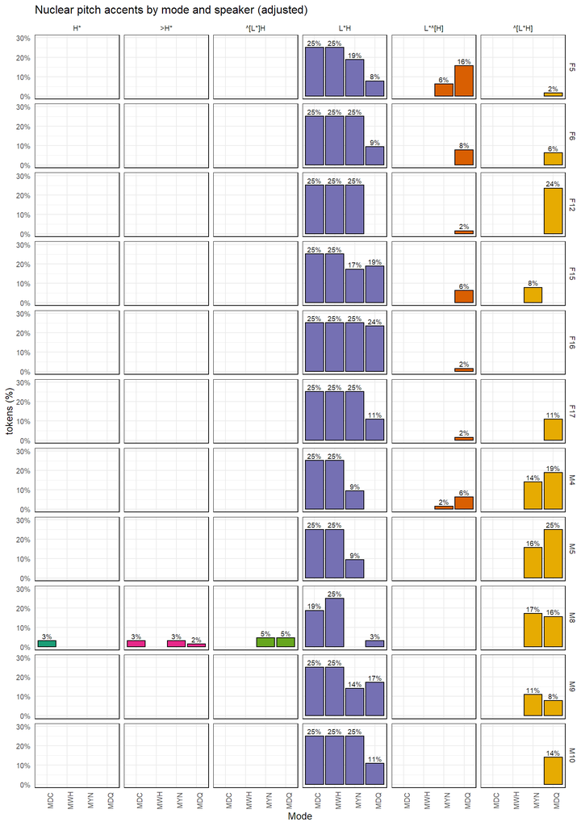

```r
ggplot(
  pa_by_mode_speaker_adj %>%
    # Uncount tables bar chart.
    pivot_longer(3:last_col(), "acc_phon") %>%
    uncount(value) %>%
    mutate(acc_phon = factor(
      acc_phon,
      levels = c("H*", ">H*", "^[L*]H", "L*H", "L*^[H]", "^[L*H]")
    ))
) +
  geom_bar(
    mapping = aes(
      x = mode,
      y = 11 * (..count..) / sum(..count..),
      fill = acc_phon
    ),
    show.legend = F,
    colour = "black",
    position = position_dodge2(preserve = "single")
  ) +
  geom_text(aes(
    x = mode,
    y = 11 * (..count..) / sum(..count..),
    label = 11 * percent((..count..) / sum(..count..), 0)
  ),
  stat = "count",
  vjust = -0.35,
  size = 2.5
  ) +
  scale_y_continuous(labels = scales::percent, limits = c(0, 0.30)) +
  facet_grid(rows = vars(speaker), cols = vars(acc_phon)) +
  ggtitle("Nuclear pitch accents by mode and speaker (adjusted)") +
  theme(
    panel.border = element_rect(fill = NA),
    axis.text.x = element_text(angle = 90, size = 7.5),
    axis.text.y = element_text(size = 7.5),
    # axis.text.x = element_text(, vjust = 0.5, hjust=1)
  ) +
  scale_fill_manual(values = pitch_accent_colours, name = "Pitch Accent") +
  labs(x = "Mode", y = "tokens (%)") +
  theme(panel.border = element_rect(fill = NA))
```

```r
ggsave(
  filename =
    "output/nuc_PA_by_mode_and_speaker.png",
  width = 15.45,
  height = 24,
  units = "cm",
  dpi = 300
)
```

## Boundary Tone Analysis

```r
fin_phon_adj <- m_corpus %>%
  mutate(fin_phon = str_replace_all(fin_phon, "\\[|\\]|\\^", "")) %>%
  mutate(fin_phon = factor(fin_phon, levels = unique(fin_phon))) %>%
  # Count the number of fin_phon by speaker and mode
  group_by(speaker, stim, fin_phon) %>%
  summarise(nuc_count = n(), .groups = "keep") %>%
  pivot_wider(
    names_from = fin_phon,
    values_from = nuc_count,
    values_fill = 0
  ) %>%
  # convert the totals to proportion per stim.
  adorn_totals("col") %>%
  mutate(across(3:(last_col() - 1), ~ (. / Total))) %>%
  select(-Total) %>%
  # Convert stim column to mode.
  rename(mode = stim) %>%
  mutate(mode = substr(mode, 1, 3)) %>%
  # Convert the values to proportion per mode
  pivot_longer(3:last_col(), "fin_phon") %>%
  group_by(speaker, mode, fin_phon) %>%
  pivot_wider(
    names_from = fin_phon,
    values_from = value,
    values_fill = 0,
    values_fn = ~ sum(.)
  ) %>%
  adorn_totals("col") %>%
  mutate(across(3:(last_col() - 1), ~ (. / Total)),
    mode = factor(mode, levels = c("MDC", "MWH", "MYN", "MDQ"))
  ) %>%
  select(-Total) %>%
  as_tibble()

# Create tibble of final boundaries per mode (adjusted).
fin_phon_by_mode_adj <- fin_phon_adj %>%
  # Get the sum of all token proportions per speaker.
  pivot_longer(3:last_col(), "fin_phon") %>%
  select(-c(speaker)) %>%
  pivot_wider(
    names_from = fin_phon,
    values_from = value,
    values_fill = 0,
    values_fn = ~ sum(.)
  ) %>%
  # Convert proportions to an integer based on an ideal total number of tokens.
  mutate(across(2:last_col(), ~ round(. * 15, 0))) %>%
  arrange(mode)

# Create tibble of final boundaries  by gender and mode (adjusted).
fin_phon_by_gender_adj <- fin_phon_adj %>%
  # Convert speaker to gender
  mutate(
    speaker = substr(speaker, 1, 1),
    speaker = factor(speaker, levels = unique(speaker))
  ) %>%
  rename(gender = speaker) %>%
  # Get the sum of all token proportions per speaker.
  pivot_longer(3:last_col(), "fin_phon") %>%
  pivot_wider(
    names_from = fin_phon,
    values_from = value,
    values_fill = 0,
    values_fn = ~ sum(.)
  ) %>%
  # Convert proportions to an integer based on an ideal total number of tokens
  # per speaker.
  mutate(across(3:last_col(), ~ if_else(gender == "F",
    round(. * 15, 0),
    # project equal number of Male & Female speakers.
    round(. * 18, 0)
  ))) %>%
  arrange(mode)

# Make lists of projected boundary tokens.
fin_phon_by_mode_adj_list <- fin_phon_by_mode_adj %>%
  pivot_longer(2:last_col(), "fin_phon") %>%
  uncount(value) %>%
  mutate(fin_phon = factor(fin_phon, levels = unique(fin_phon)))


# Get list of projected boundary tokens by mode and gender.
fin_phon_by_gender_adj_list <- fin_phon_by_gender_adj %>%
  pivot_longer(3:last_col(), "fin_phon") %>%
  uncount(value) %>%
  mutate(fin_phon = factor(fin_phon, levels = unique(fin_phon)))
```

### by sentence mode

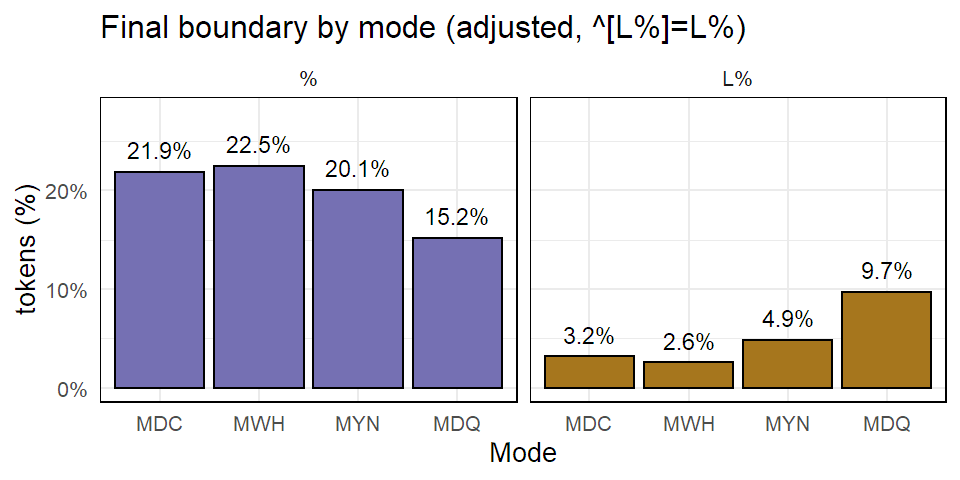

```r
ggplot(fin_phon_by_mode_adj_list) +
  geom_bar(
    mapping = aes(
      x = mode,
      y = (..count..) / sum(..count..),
      fill = fin_phon
    ),
    show.legend = F,
    colour = "black",
    position = position_dodge2(preserve = "single")
  ) +
  scale_y_continuous(labels = scales::percent, limits = c(0, 0.28)) +
  facet_grid(cols = vars(fin_phon)) +
  theme(
    panel.border = element_rect(fill = NA)
  ) +
  ggtitle("Final boundary by mode (adjusted, ^[L%]=L%)") +
  scale_fill_manual(values = fin_phon_colours, name = "final boundary") +
  labs(x = "Mode", y = "tokens (%)") +
  theme(panel.border = element_rect(fill = NA)) +
  geom_text(aes(
    x = mode,
    y = (..count..) / sum(..count..),
    label = percent((..count..) / sum(..count..), 1)
  ),
  stat = "count",
  vjust = -0.75,
  size = 3
  )
```

### by sentence mode and gender

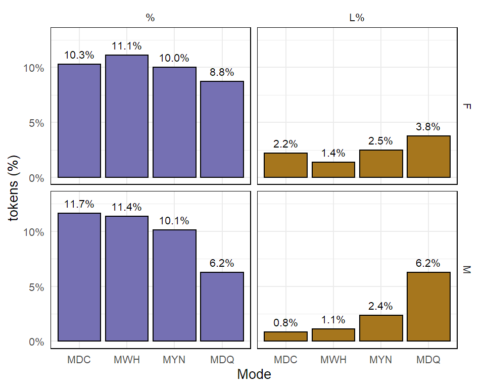

```r
ggplot(fin_phon_by_gender_adj_list) +
  geom_bar(
    mapping = aes(
      x = mode,
      y = (..count..) / sum(..count..),
      fill = fin_phon
    ),
    show.legend = F,
    colour = "black",
    position = position_dodge2(preserve = "single")
  ) +
  scale_y_continuous(labels = scales::percent, limits = c(0, 0.13)) +
  facet_grid(rows = vars(gender), cols = vars(fin_phon)) +
  theme(
    panel.border = element_rect(fill = NA)
  ) +
  ggtitle("Final boundary by mode and gender") +
  scale_fill_manual(values = fin_phon_colours, name = "nuclear contour") +
  labs(x = "Mode", y = "tokens (%)") +
  theme(
    panel.border = element_rect(fill = NA),
    plot.title = element_blank()
  ) +
  geom_text(aes(
    x = mode,
    y = (..count..) / sum(..count..),
    label = percent((..count..) / sum(..count..), 1)
  ),
  stat = "count",
  vjust = -0.75,
  size = 2.75
  )
```

```r
ggsave(
  filename =
    "output/fin_phon_reg_tier.png",
  width = 8.5,
  height = 8,
  units = "cm",
  dpi = 300
)
```

## BGLMM Analysis

### H-Register and Mode

```r
m_corpus_h_reg <- m_corpus %>%
  select(prompt, speaker, gender, nuc_H_reg, mode)


h_reg_model <- bglmer(
  nuc_H_reg ~ mode + gender + (1 | speaker) + (1 | prompt),
  data = m_corpus_h_reg,
  family = binomial(link = "logit"),
  fixef.prior = normal()
)


h_reg_model <- optimizeModel(h_reg_model, reject_nm = F)
```

#### LRT

```r
write <- "output/Mode_PA_GLMM"

model_formula <- getModelFormula(h_reg_model)

write(
  paste(str_replace_all(model_formula, "\\`", ""), sep = ""),
  paste(write, "_formula.txt", sep = "")
)


# get, save, and print ANOVA of model
drop1_analysis <- drop1(h_reg_model, test = "Chisq") %>%
  tidy() %>%
  filter(!is.na(npar)) %>%
  mutate(`p.adj (BH)` = NA, signif. = NA) %>%
  rename(factor = term) %>%
  rename(`Pr(Chi)` = Pr.Chi.) %>%
  write_csv(paste0(write, "_anova.csv"))


adjustP_posthoc("output/",
  `Pr(Chi)`,
  suffix_id = "_anova"
)

read_csv(paste(write, "_anova.csv", sep = "")) %>%
  tidyStatNumbers() %>%
  formattable(caption = paste("Drop 1 ChiSq test of model:", model_formula))
```

Drop 1 ChiSq test of model: nuc_H_reg ~ mode + gender + (1 | speaker) + (1 | prompt)

| factor | npar | AIC | LRT | Pr(Chi) | p.adj (BH) | signif. |
| --- | --- | --- | --- | --- | --- | --- |
| mode | 3 | 652.71 | 320.5 | < .001 | < .001 | *p* < .05 |
| gender | 1 | 341.59 | 5.38 | .02 | .027 | *p* < .05 |

#### *R*<sup>2</sup> and prediction plots

Conditional and marginal R<sup>2</sup> of model

| marginal R<sup>2</sup> | conditional R<sup>2</sup> |
| --- | --- |
| .69 | .79 |

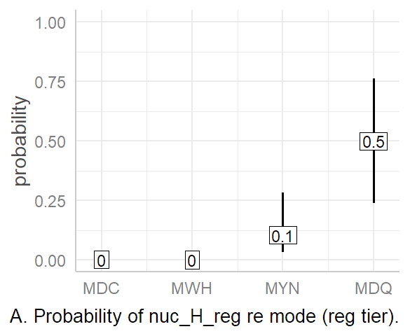

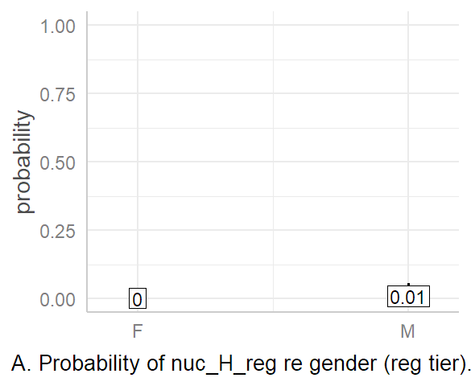

```r
tidy_summary <- analyseModel(
  h_reg_model,
  write = write,
  is_GLM = T,
  type = "pred",
  caption_suffix = " (reg tier)",
  plot_rounding = 2,
  short_caption = T,
  panel_prefix = "A. Probability of"
)
```

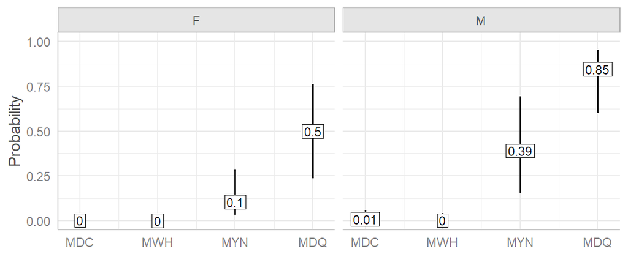

```r
ggpredict(h_reg_model,
  terms = c("mode", "gender"),
  ci.lvl = 0.95
) %>%
  plot(grid = T, colors = "bw") +
  geom_label(
    aes(label = round(predicted, 2)),
    label.padding = unit(0.5, "mm"),
    label.r = unit(0.0, "mm"),
    size = 3
  ) +
  scale_y_continuous(limits = c(0, 1)) +
  ylab("Probability") +
  theme(
    plot.title = element_blank(),
    axis.title.x = element_blank(),
    plot.caption = element_text(hjust = 0, size = 10),
    plot.caption.position = "plot",
    legend.position = c(0.12, 0.8),
    legend.background = element_rect(colour = "darkGray")
  )
```

```r
ggsave(
  filename =
    paste0(write, "_multi_pred.png"),
  # width = 8.14,
  width = 15.45,
  height = 6.26,
  units = "cm",
  dpi = 300
)
```

#### prediction by factor

```r
printTidyPredictions(h_reg_model,
  caption_suffix = " (reg tier)",
  digits = 3
)
```

Predicted probabilities of nuc_H_reg (reg tier)

| mode | predicted | conf.low | conf.high | std.error |
| --- | --- | --- | --- | --- |
| MDC | 0.002 | < 0.001 | 0.011 | 0.953 |
| MWH | < 0.001 | < 0.001 | 0.008 | 1.668 |
| MYN | 0.105 | 0.033 | 0.283 | 0.622 |
| MDQ | 0.499 | 0.237 | 0.762 | 0.594 |

Predicted probabilities of nuc_H_reg (reg tier)

| gender | predicted | conf.low | conf.high | std.error |
| --- | --- | --- | --- | --- |
| F | 0.002 | < 0.001 | 0.011 | 0.953 |
| M | 0.009 | 0.001 | 0.056 | 0.951 |

#### prediction by mode and gender

```r
x <- printTidyPredictions(h_reg_model,
  caption_suffix = " (reg tier)",
  digits = 3,
  factor_matrix = T
)
```

predicted probability of nuc_H_reg

| group | estimate | predicted | conf.low | conf.high | std.error |
| --- | --- | --- | --- | --- | --- |
| F | MDC | 0.002 | < 0.001 | 0.011 | 0.953 |
| F | MWH | < 0.001 | < 0.001 | 0.008 | 1.668 |
| F | MYN | 0.105 | 0.033 | 0.283 | 0.622 |
| F | MDQ | 0.499 | 0.237 | 0.762 | 0.594 |
| M | MDC | 0.009 | 0.001 | 0.056 | 0.951 |
| M | MWH | 0.002 | < 0.001 | 0.042 | 1.664 |
| M | MYN | 0.39 | 0.154 | 0.692 | 0.641 |
| M | MDQ | 0.845 | 0.6 | 0.952 | 0.659 |

#### Pairwise comparisons

```r
charts <- getModelFixedFX(
  h_reg_model,
  write = write,
  exponentiate = T
)
# charts$intercepts %>% tidyStatNumbers()
charts$slopes %>% tidyStatNumbers()
```

b1 for nuc_H_reg ~ mode + gender + (1 | speaker) + (1 | prompt)

[output not shown]

#### Model printout

```r
summary(h_reg_model)
```

```
## Cov prior  : speaker ~ wishart(df = 3.5, scale = Inf, posterior.scale = cov, common.scale = TRUE)
##            : prompt ~ wishart(df = 3.5, scale = Inf, posterior.scale = cov, common.scale = TRUE)
## Fixef prior: normal(sd = c(10, 2.5, ...), corr = c(0 ...), common.scale = FALSE)
## Prior dev  : 33.7782
##
## Generalized linear mixed model fit by maximum likelihood (Laplace
##   Approximation) [bglmerMod]
##  Family: binomial  ( logit )
## Formula: nuc_H_reg ~ mode + gender + (1 | speaker) + (1 | prompt)
##    Data: m_corpus_h_reg
##
##      AIC      BIC   logLik deviance df.resid
##    338.2    369.4   -162.1    324.2      632
##
## Scaled residuals:
##     Min      1Q  Median      3Q     Max
## -3.8269 -0.1790 -0.0447 -0.0150  3.0599
##
## Random effects:
##  Groups  Name        Variance Std.Dev.
##  speaker (Intercept) 1.5153   1.2310
##  prompt  (Intercept) 0.1848   0.4299
## Number of obs: 639, groups:  speaker, 11; prompt, 3
##
## Fixed effects:
##             Estimate Std. Error z value Pr(>|z|)
## (Intercept)  -6.3898     0.9529  -6.706 2.00e-11 ***
## modeMWH      -1.7054     1.5900  -1.073   0.2835
## modeMYN       4.2430     0.7605   5.580 2.41e-08 ***
## modeMDQ       6.3876     0.7865   8.121 4.61e-16 ***
## genderM       1.6990     0.7697   2.207   0.0273 *
## ---
## Signif. codes:  0 '***' 0.001 '**' 0.01 '*' 0.05 '.' 0.1 ' ' 1
##
## Correlation of Fixed Effects:
##         (Intr) modMWH modMYN modMDQ
## modeMWH -0.216
## modeMYN -0.759  0.273
## modeMDQ -0.783  0.261  0.915
## genderM -0.406 -0.004  0.024  0.070
```

### Final Boundary and Mode

- Random intercepts only since models with random slopes generate singularity issues.

```r
m_corpus_boundaries <- m_corpus %>%
  mutate(`L%` = factor(str_replace_all(fin_phon, "\\[|\\]|\\^", ""),
    levels = c("%", "L%")
  ))

fin_phon_model <- bglmer(
  `L%` ~ mode + gender + (1 | speaker) + (1 | prompt),
  data = m_corpus_boundaries,
  family = binomial(link = "logit"),
  control = glmerControl(
    optimizer = "optimx",
    calc.derivs = F,
    optCtrl = list(
      method = "nlminb",
      starttests = F,
      kkt = F
    )
  )
)

fin_phon_model <- optimizeModel(fin_phon_model, reject_nm = F)
```

#### LRT

```r
write <- "output/Mode_fin_phon_GLMM"

model_formula <- getModelFormula(fin_phon_model)

write(
  paste(str_replace_all(model_formula, "\\`", ""), sep = ""),
  paste(write, "_formula.txt", sep = "")
)


# get, save, and print ANOVA of model
drop1_analysis <- drop1(fin_phon_model, test = "Chisq")

tibble(factor = row.names(drop1_analysis)) %>%
  cbind(tibble(drop1_analysis)) %>%
  filter(!is.na(npar)) %>%
  mutate(`p.adj (BH)` = NA, signif. = NA) %>%
  write_csv(paste0(write, "_anova.csv"))


adjustP_posthoc("output/",
  `Pr(Chi)`,
  suffix_id = "_anova"
)

read_csv(paste(write, "_anova.csv", sep = "")) %>%
  tidyStatNumbers() %>%
  formattable(caption = paste("Drop 1 ChiSq test of model:", model_formula))
```

Drop 1 ChiSq test of model: `L%` ~ mode + gender + (1 | speaker) + (1 | prompt)

| factor | npar | AIC | LRT | Pr(Chi) | p.adj (BH) | signif. |
| --- | --- | --- | --- | --- | --- | --- |
| mode | 3 | 481.66 | 62.77 | < .001 | < .001 | *p* < .05 |
| gender | 1 | 422.93 | 0.04 | .838 | .914 |  |

#### *R*<sup>2</sup> and prediction plots

Conditional and marginal R<sup>2</sup> of model

| marginal R<sup>2</sup> | conditional R<sup>2</sup> |
| --- | --- |
| .07 | .79 |

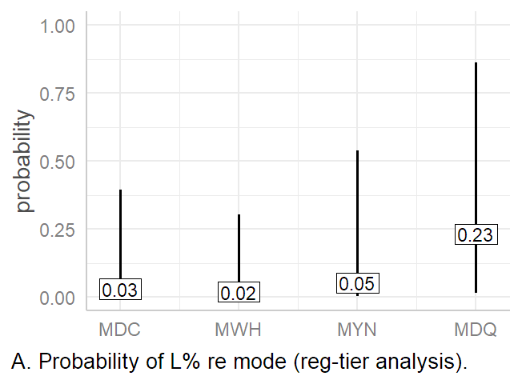

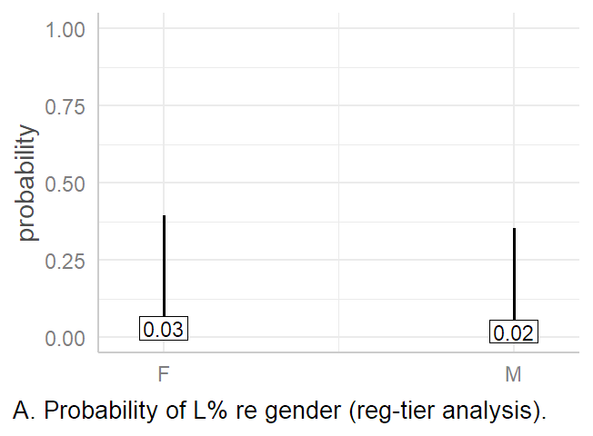

```r
tidy_summary <- analyseModel(
  fin_phon_model,
  write = write,
  is_GLM = T,
  type = "pred",
  caption_suffix = " (reg-tier analysis)",
  plot_rounding = 2,
  short_caption = T,
  panel_prefix = "A. Probability of"
)
```

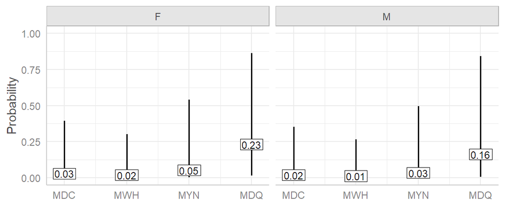

```r
ggpredict(fin_phon_model,
  terms = c("mode", "gender"),
  ci.lvl = 0.95
) %>%
  plot(grid = T, colors = "bw") +
  geom_label(
    aes(label = round(predicted, 2)),
    label.padding = unit(0.5, "mm"),
    label.r = unit(0.0, "mm"),
    size = 3
  ) +
  scale_y_continuous(limits = c(0, 1)) +
  ylab("Probability") +
  theme(
    plot.title = element_blank(),
    axis.title.x = element_blank(),
    plot.caption = element_text(hjust = 0, size = 10),
    plot.caption.position = "plot",
    legend.position = c(0.12, 0.8),
    legend.background = element_rect(colour = "darkGray")
  )
```

```r
ggsave(
  filename =
    paste0(write, "_multi_pred.png"),
  # width = 8.14,
  width = 14,
  height = 6.26,
  units = "cm",
  dpi = 300
)
```

#### prediction by factor

```r
printTidyPredictions(fin_phon_model,
  caption_suffix = " (reg tier)",
  digits = 3
)
```

Predicted probabilities of L% (reg tier)

| mode | predicted | conf.low | conf.high | std.error |
| --- | --- | --- | --- | --- |
| MDC | 0.029 | 0.001 | 0.393 | 1.57 |
| MWH | 0.019 | < 0.001 | 0.302 | 1.576 |
| MYN | 0.052 | 0.003 | 0.54 | 1.564 |
| MDQ | 0.231 | 0.014 | 0.863 | 1.551 |

Predicted probabilities of L% (reg tier)

| gender | predicted | conf.low | conf.high | std.error |
| --- | --- | --- | --- | --- |
| F | 0.029 | 0.001 | 0.393 | 1.57 |
| M | 0.019 | < 0.001 | 0.352 | 1.705 |

#### prediction by mode and gender

```r
x <- printTidyPredictions(fin_phon_model,
  caption_suffix = " (reg tier)",
  digits = 3,
  factor_matrix = T
)
```

predicted probability of L%

| group | estimate | predicted | conf.low | conf.high | std.error |
| --- | --- | --- | --- | --- | --- |
| F | MDC | 0.029 | 0.001 | 0.393 | 1.57 |
| F | MWH | 0.019 | < 0.001 | 0.302 | 1.576 |
| F | MYN | 0.052 | 0.003 | 0.54 | 1.564 |
| F | MDQ | 0.231 | 0.014 | 0.863 | 1.551 |
| M | MDC | 0.019 | < 0.001 | 0.352 | 1.705 |
| M | MWH | 0.013 | < 0.001 | 0.266 | 1.711 |
| M | MYN | 0.034 | 0.001 | 0.496 | 1.7 |
| M | MDQ | 0.162 | 0.007 | 0.843 | 1.694 |

#### pairwise comparisons

```r
charts <- getModelFixedFX(
  fin_phon_model,
  write = write,
  exponentiate = T
)
# charts$intercepts
charts$slopes %>% tidyStatNumbers()
```

b1 for L% ~ mode + gender + (1 | speaker) + (1 | prompt)

| intercept | slope | estimate | conf.low | conf.high | std.error | z.value | p.value |
| --- | --- | --- | --- | --- | --- | --- | --- |
| modeMDC | modeMWH | 0.661 | 0.3 | 1.457 | 0.27 | -1.03 | .304 |
| modeMDC | modeMYN | 1.831 | 0.882 | 3.8 | 0.68 | 1.62 | .104 |
| modeMDC | modeMDQ | 10.1 | 4.708 | 21.6 | 3.92 | 5.95 | < .001 |
| modeMWH | modeMYN | 2.772 | 1.284 | 5.983 | 1.09 | 2.6 | .009 |
| modeMWH | modeMDQ | 15.3 | 6.8 | 34.3 | 6.3 | 6.6 | < .001 |
| modeMYN | modeMDQ | 5.509 | 2.695 | 11.3 | 2.01 | 4.68 | < .001 |
| intercept | genderM | 0.643 | 0.014 | 29.1 | 1.25 | -0.23 | .821 |

#### Model printout

```r
summary(fin_phon_model)
```

```
## Cov prior  : speaker ~ wishart(df = 3.5, scale = Inf, posterior.scale = cov, common.scale = TRUE)
##            : prompt ~ wishart(df = 3.5, scale = Inf, posterior.scale = cov, common.scale = TRUE)
## Prior dev  : -4.5085
##
## Generalized linear mixed model fit by maximum likelihood (Laplace
##   Approximation) [bglmerMod]
##  Family: binomial  ( logit )
## Formula: `L%` ~ mode + gender + (1 | speaker) + (1 | prompt)
##    Data: m_corpus_boundaries
## Control:
## glmerControl(optimizer = "optimx", calc.derivs = F, optCtrl = list(method = "nlminb",
##     starttests = F, kkt = F))
##
##      AIC      BIC   logLik deviance df.resid
##    424.9    456.1   -205.4    410.9      632
##
## Scaled residuals:
##     Min      1Q  Median      3Q     Max
## -3.7394 -0.3245 -0.1098 -0.0274  4.1437
##
## Random effects:
##  Groups  Name        Variance Std.Dev.
##  speaker (Intercept) 9.403    3.066
##  prompt  (Intercept) 2.148    1.466
## Number of obs: 639, groups:  speaker, 11; prompt, 3
##
## Fixed effects:
##             Estimate Std. Error z value Pr(>|z|)
## (Intercept)  -3.5112     1.5701  -2.236   0.0253 *
## modeMWH      -0.4147     0.4035  -1.028   0.3041
## modeMYN       0.6048     0.3725   1.623   0.1045
## modeMDQ       2.3111     0.3887   5.946 2.75e-09 ***
## genderM      -0.4412     1.9455  -0.227   0.8206
## ---
## Signif. codes:  0 '***' 0.001 '**' 0.01 '*' 0.05 '.' 0.1 ' ' 1
##
## Correlation of Fixed Effects:
##         (Intr) modMWH modMYN modMDQ
## modeMWH -0.113
## modeMYN -0.135  0.491
## modeMDQ -0.172  0.458  0.541
## genderM -0.547  0.000  0.000  0.013
```